# FML-Assignment 06

Chandima Attanayake

2024-11-17

```r
# Load necessary libraries
library(cluster)
library(dplyr)
```

```r
library(ggplot2)

# Load the wine dataset
wine <- read.csv("/Users/chandimaattanayake/Downloads/Wine-clustering-HC.csv")

# Exclude categorical variables and normalize data
wine_data <- wine[, !names(wine) %in% c("Alcohol_Level", "Ash_Content", "Color_Intensity_Group")]
wine_data <- scale(wine_data)
```

# Question 1: Hierarchical Clustering Using AGNES and DIANA

**Q1-A) AGNES Clustering with different methods and plotting dendrograms**

```r
# Q1-A) AGNES Clustering with different methods and plotting dendrograms
agnes_single <- agnes(wine_data, method = "single")
agnes_complete <- agnes(wine_data, method = "complete")
agnes_ward <- agnes(wine_data, method = "ward")
agnes_average <- agnes(wine_data, method = "average")

# Print agglomerative coefficients for each method
cat("Agglomerative Coefficients:\n")
```

```
## Agglomerative Coefficients:
```

```r
cat("Single Linkage: ", agnes_single$ac, "\n")
```

```
## Single Linkage:  0.5379128
```

```r
cat("Complete Linkage: ", agnes_complete$ac, "\n")
```

```
## Complete Linkage:  0.815931
```

```r
cat("Ward Linkage: ", agnes_ward$ac, "\n")
```

```
## Ward Linkage:  0.9419172
```

```r
cat("Average Linkage: ", agnes_average$ac, "\n")
```

```
## Average Linkage:  0.7006964
```

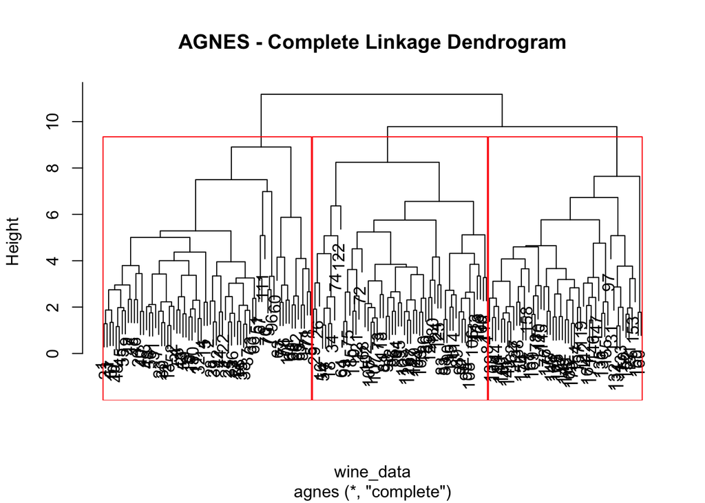

```r
# Plot dendrogram for AGNES with Complete Linkage
pltree(agnes_complete, main = "AGNES - Complete Linkage Dendrogram")
rect.hclust(as.hclust(agnes_complete), k = 3, border = "red")
```

```r
# Q1-A) DIANA Clustering and dendrogram
diana_clustering <- diana(wine_data)
cat("Divisive Coefficient (DC): ", diana_clustering$dc, "\n")
```

```
## Divisive Coefficient (DC):  0.8000096
```

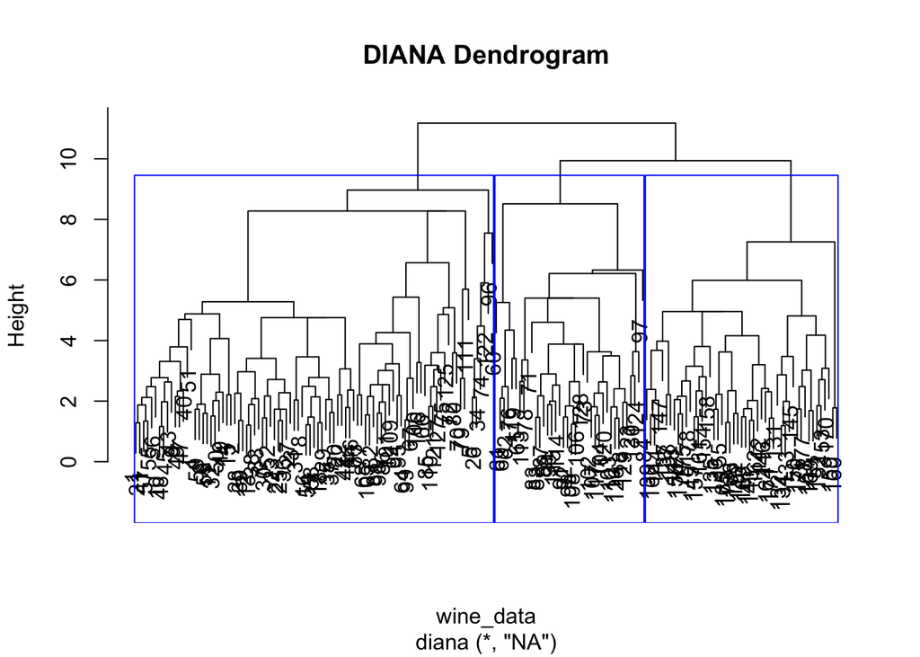

```r
# Plot dendrogram for DIANA
pltree(diana_clustering, main = "DIANA Dendrogram")
rect.hclust(as.hclust(diana_clustering), k = 3, border = "blue")
```

**Q1-B) Compare AGNES and DIANA Coefficients**

AGNES’s AC vs DIANA’s DC will help in determining the more cohesive method

From the above answer,the Agglomerative Coefficient (AC) from AGNES method is as follows.

Single Linkage: 0.5379 Complete Linkage: 0.8159 Ward Linkage: 0.9419 Average Linkage: 0.7007

Also, Divisive Coefficient (DC) from DIANA is 0.8000

Comparison

The highest AC for AGNES is Ward Linkage (0.9419), which is greater than the DC of DIANA (0.8000). Therefore, AGNES with Ward Linkage provides a more cohesive clustering structure and it will be the preferred method.

# Question 2: Visualize Categorical Variables

**Q2-A) Calculate medians for each level of categorical variables**

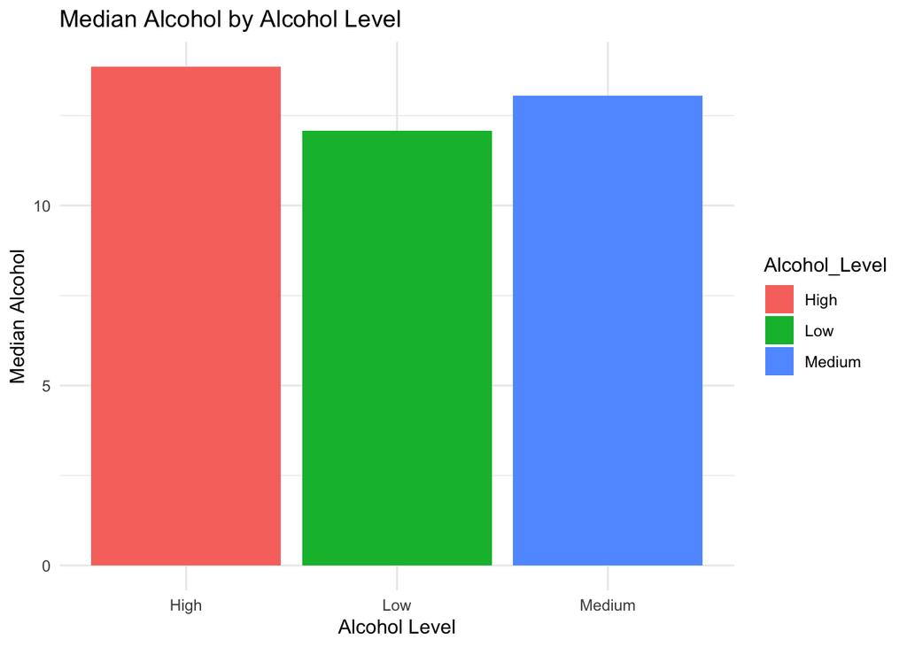

```r
# Q2-A) Calculate medians for each level of categorical variables
median_alcohol <- wine %>%
  group_by(Alcohol_Level) %>%
  summarise(Median_Alcohol = median(Alcohol, na.rm = TRUE))

median_ash <- wine %>%
  group_by(Ash_Content) %>%
  summarise(Median_Ash = median(Ash, na.rm = TRUE))

median_color_intensity <- wine %>%
  group_by(Color_Intensity_Group) %>%
  summarise(Median_Color_Intensity = median(Color_Intensity, na.rm = TRUE))

# Q2-B) Create bar plots of medians for categorical variables

# Alcohol Level Bar Plot
ggplot(median_alcohol, aes(x = Alcohol_Level, y = Median_Alcohol, fill = Alcohol_Level)) +
  geom_bar(stat = "identity") +
  labs(title = "Median Alcohol by Alcohol Level", x = "Alcohol Level", y = "Median Alcohol") +
  theme_minimal()
```

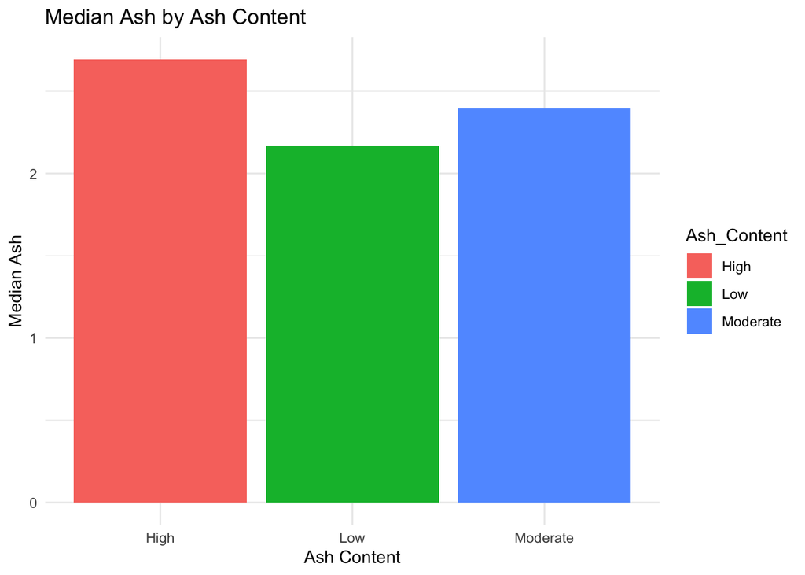

```r
# Ash Content Bar Plot
ggplot(median_ash, aes(x = Ash_Content, y = Median_Ash, fill = Ash_Content)) +
  geom_bar(stat = "identity") +
  labs(title = "Median Ash by Ash Content", x = "Ash Content", y = "Median Ash") +
  theme_minimal()
```

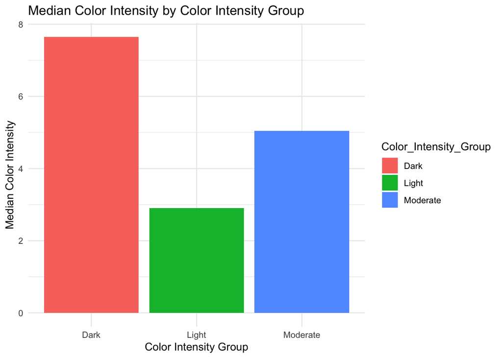

```r
# Color Intensity Group Bar Plot
ggplot(median_color_intensity, aes(x = Color_Intensity_Group, y = Median_Color_Intensity, fill = Color_Intensity_Group)) +
  geom_bar(stat = "identity") +
  labs(title = "Median Color Intensity by Color Intensity Group", x = "Color Intensity Group", y = "Median Color Intensity") +
  theme_minimal()
```

**Q2-C) Interpretation: Analyze the patterns seen in these bar plots to interpret characteristics**

The bar plots show the median values of numeric variables (e.g., alcohol, ash content, and color intensity) across categorical levels. Key observations from the above are as follows.

Alcohol Level

Median alcohol increases with higher alcohol levels.In this case, higher alcohol levels likely indicate richer flavor profiles, possibly due to more mature grapes or higher sugar content during fermentation.

Ash Content

Ash median levels vary by ash content categories. Differences in ash content reflect variations in mineral properties of the wine, influencing taste and balance.

Color Intensity

Median color intensity increases with higher intensity categories. Wines with higher color intensity likely have stronger flavors, higher tannins, and deeper pigmentation, often indicating more robust wine varieties.

The median values suggest clear patterns that can be used for categorizing and evaluating wine characteristics.

# Question 3: Determine Appropriate Clustering Technique

**Q3-A) Analyze and compare the clustering results of AGNES and DIANA.**

Both AGNES (using Complete Linkage or Ward Linkage) and DIANA form three clusters. However, the separation quality in AGNES is very good as shown by the higher AC values. Also, AGNES with Ward Linkage shows tighter and more cohesive clusters compared to DIANA. The dendrogram from DIANA may reveal a broader, less distinct separation of data.

Addition to that, the clusters likely group wines based on significant attributes such as alcohol content, color intensity, and ash content. In this case, high alcohol wines might group together, indicating similar production styles or grape types.

Therefore, AGNES with Ward Linkage is the better choice for this dataset as it provides more cohesive clusters and clearer separation.

**Q3-B) Consider alternative clustering methods, such as K-Means or DBSCAN**

Suitability of K-Means

K-Means could work well if the dataset has clear spherical clusters and normalized data (as in this case). It is efficient and simpler than hierarchical methods.However, K-Means struggles with non-spherical clusters and may be sensitive to initial centroids and outliers.

Suitability of DBSCAN

DBSCAN can handle arbitrary-shaped clusters and identify noise or outliers. If the wine dataset includes anomalies or has irregular cluster shapes, DBSCAN would be advantageous. Cons: It requires tuning of parameters (e.g., epsilon, minimum points) and may not perform well with very high-dimensional data.

Accordingly, K-Means might be a good alternative if the dataset is well-behaved and noise-free whereas DBSCAN would be better if the wine dataset has significant noise or clusters of varying shapes. However, AGNES (Ward Linkage) is still preferred for its interpretability and clear separation in this analysis.